# Differential Equations

Daniel Smith

26/02/2019

## Differential Equations

“Differential equations (DE) are mathematical equations that describe how a quantitiy changes as a function of one or several (independent) variables, often time or space. These differential equations play an important role in the sciences”

“Differential equations can be seperated into stochastic versus determanistic DEs. Problems can then be split into initial value problems versus boundary value problems. One also distinguishes ordinary differential equations from delay differential equations, partial differential equations, differenatial algebraic equations”

One of the most comprehensive packages for solving differential equations in R is called `desolve`. Here we will discuss and work through some examples of solving many differential equations with R and the `desolve` package.

## Logistic Growth

“In an ODE, the unknown quantity is a function of a single independent variable” - Logistic growth is perhaps one of the most common forms of differential equations present in the sciences and plays a large part in ecology and biological systems.

Differential equation:
$$\frac{dN}{dt} = rN(1-\frac{N}{K})$$
Analytical solution:
$$N_{t} = \frac{KN_{0}e^{rt}}{K+N_{0}(e^{rt}-1)}$$
R implementation:

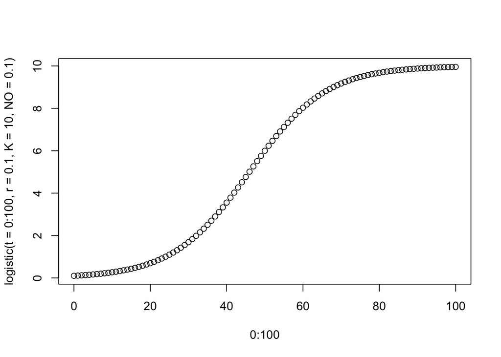

```r
logistic <- function(t, r, K, NO) {
  K * NO * exp(r * t) / (K + NO * (exp(r * t) - 1))
}

plot(0:100, logistic(t = 0:100, r = 0.1, K = 10, NO = 0.1))
```

## A Simple ODE: Atmospheric Chaos

The Lorenz equations were the first chatioc dynamic system to be described. They consist of three differential equations used to represent the idealised behaviour of the earths atmosphere for three state variables, *X*, *Y*, and *Z*.

$$\frac{dX}{dt} = aX+YZ$$
$$\frac{dY}{dt} = b(Y-Z)$$
$$\frac{dZ}{dt} = -XY+cY-Z$$

Implementation of an ODE in R can be seperated into two parts, model specification and model application.

Model Specification: * Defining the model parameters and their values * Defining model state variables and their initial conditions * Implementing the model equations that calculate the rate of change of the state variables (e.g. *dX/dt*)

Model Application: * Specification of the time at which the model output is wanted * Intergration of the model equations (uses R-functions from deSolve) * PLotting the model results

### 1.1 Model Specification